# Statutory homelessness in England: April to June 2018

### Experimental Statistical Release

13 December 2018

1. Introduction

2. Initial assessment of duties owed

3. Main homelessness duty owed

4. Prevention duties ended

5. Relief duties ended

6. Main duties ended

7. Households in temporary accommodation

8. Accompanying tables

9. Technical notes

### Headline statistics for April to June 2018:

- The Homelessness Reduction Act (HRA) 2017 commenced on 3 April 2018. The HRA amended the Housing Act 1996, creating new duties on local authorities in England. Between 3 April and 30 June 2018, 58,660 households were owed a new statutory homeless duty. Of these 33,330 households were owed a new prevention duty and 25,330 households were owed a new relief duty.
- Between 3 April and 30 June 2018 local authorities accepted 6,670 households as being owed a main homelessness duty.
- On 30 June the number of households in temporary accommodation was 82,310, up 5% from 78,540 on 30 June 2017, and up 71% on the low of 48,010 on 31 December 2010.
- Between 3 April and 30 June 2018, prevention and relief duties ended for 10,800 households by securing accommodation for 6 months or more

The statistics in this report are published as Experimental Official Statistics. They are the first set of statistics since commencement of the Homelessness Reduction Act (HRA) on 3 rd April 2018 and the first statistical release using Homelessness Case Level Information Collection (H-CLIC) data. The figures in this release are not directly comparable with previously published figures. We are continuing to work with local authorities to improve the quality of the data and therefore these are provisional figures and will be revised in the next publication.

This quarter’s figures are based on full or partial returns for 322 out of 326 local authorities (98% response rate). The impact of missing data for these 4 local authorities differs by data section. Complete temporary accommodation data was provided by 299 (92%) local authorities. The temporary accommodation data for the remaining 27 local authorities was imputed using previous quarter’s returns and a quarter on quarter change observed in groups of local authorities.

## 1. Introduction

This release includes data on the actions of 322 of the 326 lower tier local authorities in England under their legal duties towards homeless households[^1] and households threated with homelessness. The data in this release are used to identify the broad characteristics and circumstances of households owed a statutory homelessness duty (see definition below). As this is the first publication using the new data collection system, missing values have been treated differently. Usually these would be imputed to ensure national headline figures are representative. However, for the new prevention and relief duties, imputation has not been possible as there is no data for previous quarter to compare against. Imputation has been carried out for missing temporary accommodation figures so that it can be compared to data for previous quarters, although care should be taken in making direct comparisons as small changes could be due to streamlining the reporting standard for these cases. Further details are included in the data quality section.

This release does not provide data on the definitive number of people or households affected by homelessness in England. The data in this release excludes anyone who is rough sleeping, the hidden homeless and those living in overcrowded or inhabitable conditions that have not approached their local authority for assistance. MHCLG publish a separate release in January on annual autumn rough sleeping counts and estimates (see Related Statistics in the Technical notes section for links to other sources).

### Statutory Homelessness

#### Definition: Statutory homelessness

**Statutory homelessness** covers all households who are owed a homelessness duty by a local authority. A household is considered statutorily homeless if a local authority decides that they do not have a legal right to occupy accommodation that is accessible, physically available and which would be reasonable for the household to continue to live in. The Housing Act 1996 (as amended by the Homelessness Act 2002, Localism Act 2011 and the Homelessness Reduction Act 2017[^2]) determines the legal duties on local authorities towards homeless households and households threatened with homelessness.

**The Homelessness Reduction Act (HRA)** significantly amended homelessness legislation. The Act introduced a number of changes including:

- A strengthened duty to provide advisory services
- An extension to the period during which an applicant considered ‘threatened with homelessness’ from 28 to 56 days
- New duties to asses all eligible applicants (not just those unintentionally homeless and in priority need) and to take reasonable steps to prevent and relieve homelessness.
- These steps will be set out in a personalised housing plan that, wherever possible, must be agreed between the local authority and the applicant.

#### Definition: New legal duties

Households who are statutorily homeless are owed legal duties that fall into three main categories:

- **Prevention duties** include any activities aimed at preventing a household threatened with homelessness from becoming homeless. This would involve activities to enable an applicant to remain in their current home or find alternative accommodation in order to prevent them from becoming homeless. The duty lasts for 56 days, but may be extended if the local authority is continuing with efforts to prevent homelessness.
- **Relief duties** are owed to households that are already homeless and require help to secure settled accommodation. The duty lasts 56 days, and can only be extended by a local authority if the households would not be owed the main homelessness duty.
- **Main homelessness duty** describes the duty a local authority has towards an applicant who is unintentionally homeless, eligible for assistance and has priority need3. This definition has not been changed by the 2017 HRA. However, these households are now only owed a main duty if their homelessness has not been successfully prevented or relieved.

### Experimental statistics and H-CLIC

The statistics in this release are Experimental Statistics and should be treated as provisional. This reflects not only the need for local authorities to report on new legal duties with the introduction of the HRA but also the introduction of a new data reporting system. From 1 April 2018 the **Homelessness Case Level Information Collection (H-CLIC)** data system replaced the aggregated data return (collected using the P1E form) for all new homeless applications. This new system collects more detailed data than previously on households, activities offered to assist them, and their outcomes. Any cases that were taken on by local authorities prior to the commencement of the Act on the 3 April 2018 can be reported via H-CLIC or P1E during 2018-19. The P1E aggregate form will be phased out completely and replaced by H-CLIC for reporting updates on all cases from the 1 April 2019. Data that is still reported through both H-CLIC and P1E will be identified in this publication and any inconsistencies or concerns highlighted. The purpose of the experimental statistics designation is to help inform regular users of the data quality issues and omissions that occur when a new data collection methodology is implemented. Every effort has been made to ensure the data in this publication is of suitable quality. However, in some instances there are omissions in data at the local authority level which may affect the England totals. Where issues have been identified these are clearly marked and explained in both the relevant data tables and in the main release. Users should also be aware that the format and content of the release will change as the quality of data in the new fields improves. Some information will only be published annually when sufficient data are available to avoid suppression issues. We are grateful for the effort of many local authorities in ensuring their data was submitted and working with us to resolve quality issues.

The H-CLIC data specification, with detailed guidance for each field and guidance on how to enter the data through MHCLG’s DELTA system, are all available on a dedicated [Homelessness Statistics User Forum webpage](https://gss.civilservice.gov.uk/guidances/mhclg-homelessness-statistics-user-forum/). MHCLG have also published a series of newsletters about progress on the H-CLIC project which are also available on the webpage.

This is the first release based on the HCLIC return. Quarterly data will continue to be collected and reported in regular releases. Revisions to previous quarters will be published as required to reflect improvements in data quality and completeness. Feedback is welcomed on the content, structure and usefulness of the Experimental Statistics published. Please email any enquiries, comments or suggestions for future releases to homelessnessstatistics@communities.gov.uk.

## 2. Initial assessment of duties owed

This section of the release covers the two duties; prevention and relief that were initially assessed as being owed between 3April and 30 June 2018. This excludes the relief duties that followed prevention when prevention failed to secure accommodation. This section does not cover main duty assessments as these are included under section 3: Main duty acceptances.

The 2017 HRA amendments to duties mean that any household approaching a local authority for assistance on or after the 3 April 2018 was assessed under different criteria than previously. Local authorities are required to make inquiries into a homeless application whenever they have reason to believe that an applicant household may be homeless or threatened with homelessness within 56 days. Applicants threatened with becoming homeless within 56 days who are eligible for assistance, will be owed a prevention duty and those already homeless, a relief duty. These duties are owed irrespective of whether the applicant may or may not have priority need, or be considered to be ‘intentionally homeless’.

**Figure 1: Initial assessment of homeless duties owed to households**

England, April to June 2018

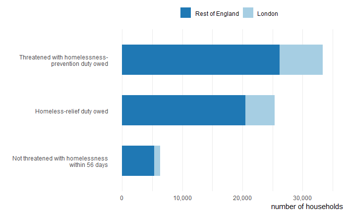

[download this chart’s data (csv)](https://github.com/adam-p/markdown-here/wiki/Markdown-Cheatsheet#hr)

Between April to June 2018, 64,960 homelessness assessments were made under the new duties, and 58,660 households were assessed as being owed a statutory homelessness duty. Of the 58,660 households, 33,330 or 57% were owed a prevention duty, 25,330 or 43% were owed a relief duty. A further 6,300 households were assessed as being not homeless or threatened with homelessness within 56 days. This figure must be treated with caution because 25 local authorities have advised that their data submission includes households who sought local authority help for other reasons than homelessness, and it has not been possible to identify the homeless applicants from within these (see Data limitations in Technical Notes).

Total households owed a new prevention or relief duty between April to June 2018 is greater than those owed a main duty between January to March 2018. This is because of the expansion of the definition of statutory homelessness to include those threatened with homelessness within 56 days nd the addition of the new duties that are owed irrespective of priority need or intentional homelessness.

### Households with support needs

The amended legislation requires local authorities to assess the support needs of homeless households, and consider how these needs might be met as part of their personalised housing plan. Support needs are not characteristics of the household, but instead are areas of additional needs that mean the household requires support to have and sustain accommodation. Where support needs are identified, the local authority should identify the steps to be taken to provide the necessary support as part of the personalised housing plan.

Support needs are reported at the household level and more than one support need could be reported per household. Therefore the total number of households receiving support will not match the total number of support needs. Support needs were only reported on cases covered by the amended legislation through H-CLIC.

Of the 58,660 households who were owed a homelessness duty, 27,580 households were identified as having support needs. There were 30,250 households, or 52% with no recorded support needs and 830 households were missing any support needs assessment. Of the 27,580 households who had a support need, 40,110 supports needs were identified, an average of 1.5 support needs per household.

The most common support need identified was a history of mental health problems which was reported by 12,700 of households with support needs. The second largest group was those with physical ill health or disability, identified by 8,190 households. Other notable groups included those with experience of domestic abuse (5,500 households), those with drug (3,090 households) and alcohol dependency needs (2,510 households). Those with a history of homelessness or rough sleeping were identified in 3,960 and 3,240 households respectively. A complete list of support needs and breakdowns at the regional level are provided in table A3 (for links see section 8: Accompanying tables section at the back of the release).

### Current accommodation

In the new H-CLIC data specification local authorities were asked to record the current accommodation at the time the household approached the local authority. Current accommodation is used to identify the settled accommodation types of those who could be prevented from becoming homeless and the unsettled accommodation of those requiring relief. There is no data to directly compare to previous quarters as this information was not separately captured in the old P1E return.

It should be noted that it is thought that ‘no fixed abode’ has been overused as a data category in the data return where living with friends or family would have been more appropriate. It is also known that the category ‘homeless on departure from institution’ was underreported as many people leaving custody typically move in with friends or family for a few days and this latter category has been used instead.

**Figure 2: Accommodation type at the time of first local authority approach**

England, April to June 2018

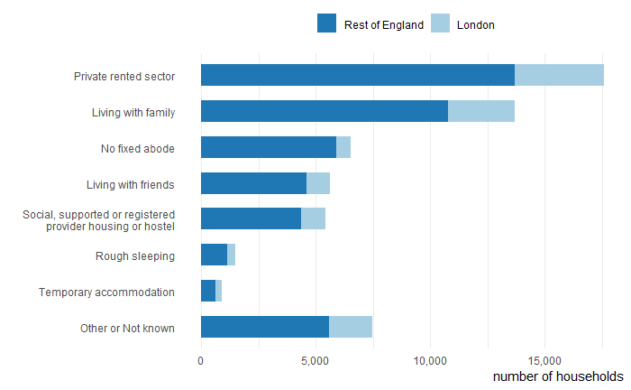

[download data for this chart(csv)](https://github.com/adam-p/markdown-here/wiki/Markdown-Cheatsheet#hr)

### Reason for loss of last settled home

Reasons for loss of last settled home for those owed a statutory homelessness duty; either prevention, relief or main duty is collected under H-CLIC and includes more detailed breakdowns of certain categories. One of the most common reasons for loss of last settled home is the end of an assured shorthold tenancy (AST). ASTs can end for a range of reasons, such as tenant difficulty budgeting, rent increase, reduction in employment income, changes to benefit entitlement, and changes to personal circumstances.

Caution should be taken when comparing any breakdowns to previous quarters as any changes will reflect the expanded population owed a homelessness duty and the nature of those duties, as well as any change in external pressures impacting on the reasons for people becoming homeless or threatened with homelessness.

**Figure 3: Reason for loss of last settled home** England, April to June 2018

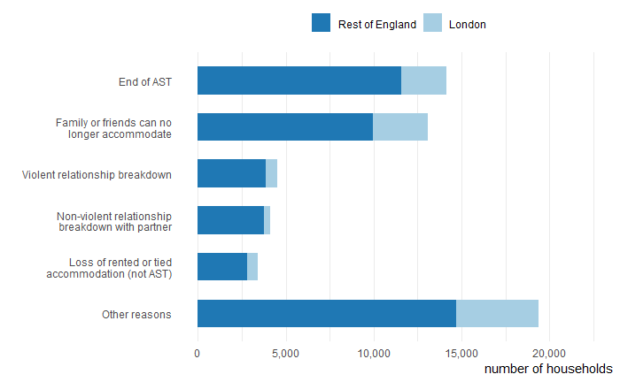

[download data for this chart(csv)](https://github.com/adam-p/markdown-here/wiki/Markdown-Cheatsheet#hr)

Between April to June 2018, the most common reason for loss of last settled home was termination of an assured shorthold tenancy. This was the main reason for 14,150 households or 24%. The second largest category for was friends or family no longer willing or able to accommodate the household, which was the reason given for 13,090 households or 22% found to be homeless. Family no longer willing to accommodate was the largest of the two categories with 10,490 households in this category.

## 3. Main homelessness duty owed

Since the amended 2017 HRA duties this release reports on the three possible routes from a person approaching a local authority for assistance to being owed a statutory homeless main duty.

Households who approached the local authority on or before the 2 April were still assessed initially for their entitlement to a main duty under the 1996 Act. Some of these assessments were completed during April to June 2018 and are included in this release.

Eligible households who were homeless or threatened with homelessness and assessed as having priority needs before 3 April 2018 were issued with a decision that they were owed a main duty. After this date, a household is first owed a relief duty or a prevention then relief duty rather than the main duty. A main duty decision may be issued on these households but this decision is only being reported after the relief duty ends in this release. The 56 days required for the relief duty to end before a main duty decision takes effect is significant for this quarter as it will mean the figures on decisions will be lower than expected and in future quarters these are likely to change.

Figure 4 shows how the total number of households owed a main homelessness duty has changed over time from Q1 1998 to Q2 2018.

**Figure 4: Main duty homelessness acceptances**

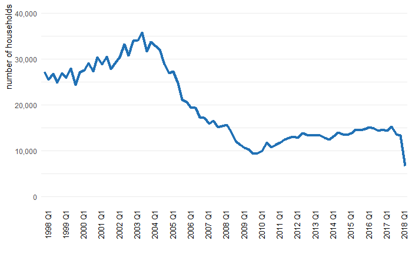

[download data for this chart(csv)](https://github.com/adam-p/markdown-here/wiki/Markdown-Cheatsheet#hr)

**Table 1[^3]: Main duty decisions, England, April to June 2018**

| Main duty decision | Number of households |
| --- | --- |
| Owed a main homelessness duty | 6,670 |
| Intentionally homeless and in priority need | 940 |
| Homeless and no priority need | 1,200 |
| Not homeless | 2,820 |

Local authorities made 11,630 main homelessness duty decisions in April to June 2018. This is 57.7% less than in the same quarter 2017. 6,670 households were accepted as owed the main duty, of these 560 had applied for assistance on or after April 3 and were assisted under the amended legislation, and 6,110 were pre-HRA applicants.

Local authorities accepted 6,670 households as owed a main homelessness duty between April to June 2018 this was 50% lower than January to March 2018. Of the 6,670 owed a main homelessness duty, 1,760 were in London, accounting for 26% of the England total.

**Figure 5: Main duty decisions**

England, April to June 2018

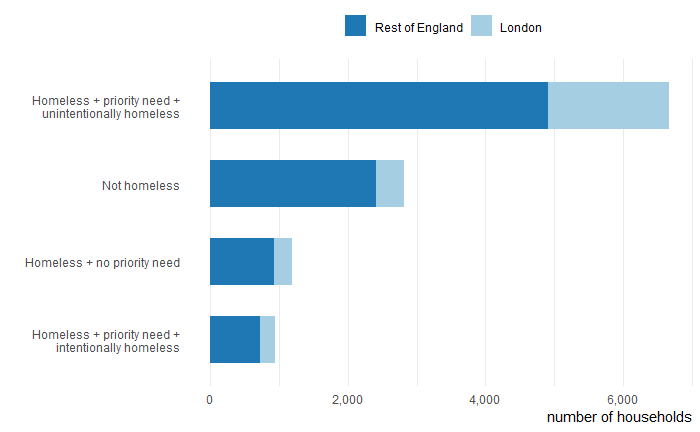

[download data for this chart(csv)](https://github.com/adam-p/markdown-here/wiki/Markdown-Cheatsheet#hr)

The corresponding figures for London and Rest of England and the percentage changes are shown in Table 2.

**Table 2[^4]: Households accepted as owed a main homelessness duty during April to June 2018 with comparisons to previous quarter and year, England, London and Rest of England, April to June 2018**

[output not shown]

The number of main homelessness duty acceptances peaked in Q3 2003 at 35,770 before falling to a low of 9,430 in Q4 2009. This quarter the number of main duty acceptances is 6,670, which is a new low. However, caution should be taken before using this number as this number is likely to change in future quarters as the new legislation and reporting systems are established.

## 4. Prevention duties ended

All eligible applicants who are threatened with homelessness within 56 days are owed by the local authority who must take reasonable steps to try and prevent them from becoming homeless. Data in this section concerns the number of duties that ended between April and June 2018, the reason why these duties ended and the activities and accommodation outcomes of those whose homelessness was prevented.

Data on prevention outcomes under new legislation is not comparable to the previous published data on prevention activities.

The new prevention duty information is only provided when a homeless application has been taken, an assessment completed and a statutory process followed. Interventions and activities that prevent a household from reaching a point where they need to make a homeless application (sometimes referred to as ‘upstream’ prevention) are not included within the data. This means that the new data will more accurately reflect action taken to assist people who have reached a point of being genuinely threatened with homelessness within 56 days, as it is drawn from case level information from applications taken.

A number of local authorities have reported issues collecting or reporting accurately on prevention duties. This also means the overall England total is underreported and should be used with caution. The data quality process is covered in more detail under Data quality and coverage in Technical notes.

Chart 6 shows data on the 10,540 households’ whose prevention duty ended between the 3 April and 30 June 2018. Of these 6,700 households, or 64% had secured their existing or alternative accommodation for at least 6 months. 2,160 of households were homeless at the end of the prevention duty and would therefore be owed a relief duty. The prevention duty ended for 60 households because the applicant refused an offer of accommodation, and for a further 50 households that deliberately and unreasonably refused to cooperate with the reasonable steps carried out by local authorities to prevent their homelessness. The prevention duty ended for other reasons for 1,570 households which includes where the authority lost contact with the client, their application was withdrawn or they ceased to be eligible for assistance.

**Figure 6: Outcome of prevention duty**

England, April to June 2018

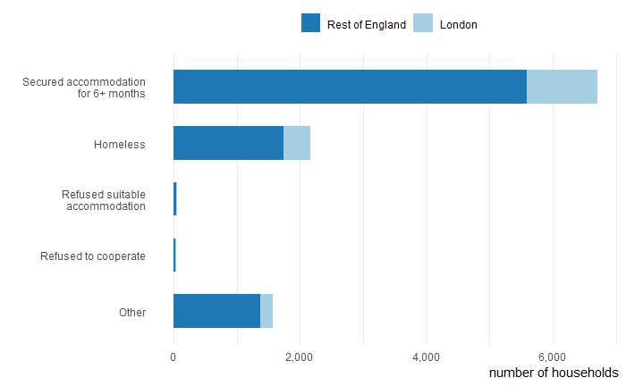

[download data for this chart(csv)](https://github.com/adam-p/markdown-here/wiki/Markdown-Cheatsheet#hr)

## 5. Relief duties ended

All eligible applicants who are actually homeless are owed a duty to take reasonable steps to try and relieve their homelessness by helping them to secure accommodation that is available for at least 6 months. Data in this section concerns the number of relief duties that ended between April and June 2018, the reason why these duties ended and the activities and accommodation outcomes of those whose homelessness was relieved.

This data is not comparable to the previous data published on relief activities. Previously published relief data was based on activities offered to households at the discretion of local authorities. These activities were discretionary because they were only offered to those who were homeless but assessed as not owed the main homelessness duty, including those who did not have priority need or were intentionally homeless. As all homeless and eligible applicants are now owed duties to try and relieve their homelessness before a main duty decision is reached, there will be an increased in the numbers receiving support to relieve homelessness and in successful relief outcomes.

As this is a new duty and the data systems on which this information is collected and reported is new a number of local authorities have reported issues recording information. These issues range from local authorities recording this information incorrectly, software issues that mean local authorities are unable to report this data or do not export all relevant cases. Local authorities that have highlighted issues that mean their data is underreported are flagged in the associated tables. This also means the overall England total is underreported and should be used with caution.

Of the 7,230 households whose relief duty ended between 3 April and 30 June 2018, 4,100 or 57% of households had secured accommodation for at least 6 months. In 1,240 households (17%), the duty ended because their homelessness had not been relieved within 56 days. For 80 households the homeless duty ended because of a refusal of a final accommodation offer and a further 50 households were served a notice for refusal to cooperate.

**Figure 7: Reason relief duty ended**

England, April to June 2018

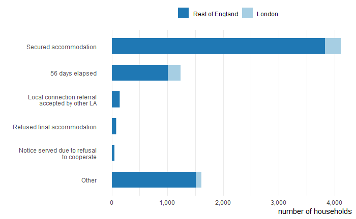

[download data for this chart(csv)](https://github.com/adam-p/markdown-here/wiki/Markdown-Cheatsheet#hr)

## 6. Main duties ended

When a household is accepted as being owed a main duty by a local authority the authority has a duty to ensure that suitable accommodation is available until such time as the duty ends. The main duty can also be brought to an end for other reasons such as the applicant turning down a suitable offer of temporary accommodation or the applicant no longer being eligible for assistance. As main duty decisions and acceptances have fallen this quarter this will have had some impact on the main duties ended. It is not known what impact the change in reporting system had on these numbers and it is likely that these figures will change in future quarters.

A main homelessness duty was ended for 7,830 households in between April to June 2018. This includes those who had previously been in temporary accommodation or had remained, with consent, in their existing accommodation while awaiting alternative accommodation. This is a 22% decrease from 10,070 in the previous quarter and a 18% decrease from 9,530, during April to June 2017.

## 7. Households in temporary accommodation

Temporary accommodation stock has been reported by local authorities through a combination of P1E and H-CLIC returns this quarter. With the introduction of H-CLIC local authorities have been given a period of time in which to they may continue to report on pre-HRA cases through the P1E, alongside their H-CLIC submissions for new legislation applications. For most local authorities new temporary accommodation placements post 3 April have been reported though H-CLIC and the remainder through the P1E return. For this reason during the 2018/19 financial year temporary accommodation data will still be limited to the P1E aggregations.

The number of households in temporary accommodation is calculated at the end of the quarter. The number represents a snapshot in time (and not the cumulative total over the quarter). This allows for effective comparison between different quarters. The number of households in temporary accommodation includes households which are:

- provided with interim accommodation until a decision is reached on whether a main duty is owed under a new application or reapplication
- awaiting a decision on whether a referral has been accepted under local connection arrangements
- undergoing a local authority review or county court appeal
- under a relief duty and priority need so eligible for temporary accommodation under amended 2017 HRA legislation.
- Homeless, eligible for assistance and in priority need and owed the main housing duty under 1996 Housing Act
- intentionally homeless and in priority need who are being accommodated for a limited period.

Figures for households in temporary accommodation have been imputed for 27 local authorities whose data had major quality issues, usually resulting from the omission of pre 2017 HRA case data. The remaining data quality issues included different initial assessment or main duty figures or broad unspecified IT issues resulting in the incorrect numbers being entered onto the DELTA system. Further details on these issues are included in the Data limitations section.

**Figure 8: Households in temporary accommodation**

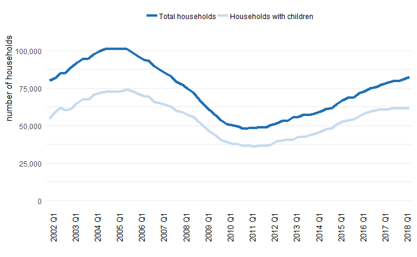

[download data for this chart(csv)](https://github.com/adam-p/markdown-here/wiki/Markdown-Cheatsheet#hr)

On 30 June 2018, the total number of households in temporary accommodation arranged by local authorities under homelessness legislation was 82,310. This was 5% higher than a year earlier and up 71% on the low of 48,010 on 31 December 2010. In London the number of households in temporary accommodation at 30 June 2018 was 56,560, 69% of the total England figure.

The corresponding figures for London and Rest of England and the percentage changes are shown in Table 3.

**Table 3[^5]: Households accommodated in temporary accommodation at 30 June 2018 compared to previous quarter and year, England, London and Rest of England**

| Geography | Households in TA on 30 Jun 2018 | Households in TA on 31 Mar 2018 | Percentage change on 31 Mar 2018 | Households in TA on 30 Jun 2017 | Percentage change on 30 Jun 2017 |
| --- | --- | --- | --- | --- | --- |
| England | 82,310 | 80,720 | 2% | 78,540 | 5% |
| London | 56,560 | 55,440 | 2% | 54,550 | 4% |
| Rest of England | 25,760 | 25,280 | 2% | 24,560 | 5% |

Comparing the number of households in temporary accommodation to the population size in an area gives a measure of its use. In England there were approximately 3.5 households living in temporary accommodation per 1,000 households at the end of June 2018. There were approximately 15.5 cases per 1,000 households in London and 1.3 cases per 1,000 households in the Rest of England.

### Types of temporary accommodation

Figure 9 shows a breakdown of households by temporary accommodation type.

**Figure 9: Households in temporary accommodation by type of accommodation**

England, April to June 2018

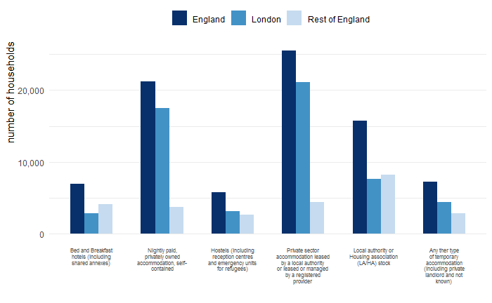

[download data for this chart(csv)](https://github.com/adam-p/markdown-here/wiki/Markdown-Cheatsheet#hr)

### Households in temporary accommodation by household type

Of the 82,310 households in temporary accommodation on 30 June 2018, 61,480 households included dependent children. Of the 61,480 households with children, 55,480 (90%) were in selfcontained accommodation.

There were 2,560 households in B&B with dependent children, 37% of all households in B&B accommodation. The number of households with children in B&B is down 3% from 2,640 in the same quarter last year and as a proportion of households, this has reduced by 3 percentage points from 40% in the second quarter of 2017.

Of the 2,560 households with children in B&B, 900 had been resident for more than the statutory limit of 6 weeks. This is up 14% from 790 on the 31 March 2018 and down 25% from 1,200 on 30 June 2017.

The corresponding figures for the previous quarter and same quarter the previous year, and percentage changes, are shown in Table 4.

**Table 4[^6]: Households accommodated in Bed and Breakfast temporary accommodation at 30 June 2018 with comparisons to previous quarter and year, England**

| Type of household | Households in B&B on 30 Jun 2018 | Households in B&B on 31 Mar 2018 | Percentage change on 31 Mar 2018 | Households in B&B on 30 Jun 2017 | Percentage change on 30 Jun 2017 |
| --- | --- | --- | --- | --- | --- |
| Total households | 6,890 | 6,130 | 12% | 6,520 | 6% |
| Households with dependent children | 2,560 | 2,190 | 17% | 2,640 | -3% |
| Of which: resident for more than 6 weeks | 900 | 790 | 14% | 1200 | -25% |

The number of households in temporary accommodation in another local authority district was 23,640. This is an increase of 1,480 from the figure for the second quarter of 2017.

## 8. Accompanying tables

Accompanying tables are available to download alongside this release. References to previously published tables are included where comparisons are possible.

**Initial decision tables**

**A1:** Initial decision of homelessness duty owed to households

**A2:** Reason for loss of last settled home for those owed a prevention or relief duty - LA

**A2:** Reason for loss of last settled home for those owed a prevention or relief duty - Regional

**A3:** Support needs of main applicant and household members for those owed a prevention and relief duty

**A4:** Accommodation at time of application for those owed a prevention or relief duty - LA

**A4:** Accommodation at time of application for those owed a prevention or relief duty - Regional

**Prevention duty tables**

**P1:**Number of households by local authority where prevention duty ended and reason the duty ended

**P2:** Number of households by region where prevention duty ended with secure accommodation by accommodation type

**P3:** Number of households by region and the main prevention activity that resulted in accommodation secured

**Relief duty tables**

**R1:** Number of households where relief duty ended and reason for the duty ending

**R2:** Accommodation outcome for households who have ended the relief duty

**R3:** Main relief activity where relief duty ended with secure accommodation

**Main duty tables**

**MD1:** Main duty decision for households by local authority

**MD1 TS:** Main duty decisions for households by quarter

**MD2:** Reason the main duty ended by local authority

**Temporary accommodation tables**

**TA1 TS:** Households in temporary accommodation at the end of the quarter

**TA1:** Local authority breakdowns of households in temporary accommodation at the end of thequarter by type

The above tables can be accessed from the [Live tables on homelessness webpage](https://www.gov.uk/government/statistical-data-sets/live-tables-on-homelessness). Related MHCLG statistical releases are available from the [Homelessness Statistics collection webpage](https://www.gov.uk/government/collections/homelessness-statistics).

## 9. Technical notes

### Data collection and methods

Local housing authorities report their activities under Part 7 of the Housing Act 1996 to the MHCLG by completing the quarterly HCLIC statistical return. HCLIC is an upload of all cases about statutory homelessness and the authority’s activities within the legislative framework.

1. Rates per 1,000 households have been calculated using the 2014-based household projections for 2017 produced by the Ministry of Housing, Communities and Local Government. These were published on 12 July 2016 and are available at Table 406 of the [2014-based live tables](https://www.gov.uk/government/statistical-data-sets/live-tables-on-household-projections).
2. National figures in the text and accompanying tables are presented rounded to the nearest 10 households or applicants. Local authority figures provided in the accompanying Live Tables are unrounded.
3. As much of the data in this release is part of a new data collection and reflects new duties owed under the 2017 amended HRA, most missing data has not been imputed and so the England level totals should be considered a provisional figure that underestimates the total. Where previous data can be used to provide trends. data has been imputed, such as in the temporary accommodation section and main duties owed or ended. However, caution should also be taken with these figures as the larger number of local authorities who have imputed figures this quarter compared to previous quarters have reduced the accuracy of these totals.

### Comparability between H-CLIC and P1E

Some data collected via P1E is **broadly comparable** to data collected via H-CLIC. The number of households in temporary accommodation is intended to be comparable although the new method of reporting means initially any suggestion of recent trends should be made with caution. The definition of main duty acceptances remains the same but the introduction of the new prevention and relief duties means there should be fewer households owed the main duty, and in this first post-HRA release there will be an impact in numbers from the delay to main duty decision s as a result of the new 56 day relief duty. Prevention and relief information collected by H-CLIC cover new legal duties so these are **not comparable** to the activity information collected in P1E. H-CLIC is a household level data collection and contains **new information not collected in the P1E return**. H-CLIC includes some information on all individuals within the household and not just the main applicant. As H-CLIC is new and still being quality assured this release contains a limited amount of data in order to publish key information activities carried out by local authorities under the new legislation. This release includes numbers of initial assessments, prevention and relief activities, main homelessness acceptances, and the number of households in temporary accommodation. In future MHCLG intend to expand the publication to include more breakdowns on the circumstances and needs of households, reasons for homelessness. Timescales will be determined by the quality of the information received by the Department. More information and guidance about the H-CLIC data collection can be found on the [Homelessness Statistics User Forum webpage](https://gss.civilservice.gov.uk/guidances/mhclg-homelessness-statistics-user-forum/).

### Data quality and coverage

All HCLIC returns submitted by local housing authorities undergo thorough validation and crosschecking and late returns are chased to ensure overall response is as complete and accurate as possible.

#### QA principles, standards and checks applied by data suppliers

Local authorities have been in a continuous dialogue with MHCLG during the first quarter reporting period to ensure validations are working correctly and are understood. A number of issues were corrected during the first quarter and further work is being undertaken by MHCLG to improve this process for future quarters.

#### Producer’s QA investigations and documentation

Case level validations in DELTA are explained with information flags marked against the reportable fields and text validation messages that help local authorities identify the cause of their mistake. Where a combination of errors are flagged MHCLG have produced a validations glossary that helped local authorities understand and correct these errors.

Many software suppliers have incorporated MHCLG’s schematron, a validation script run against the xml file, into local authority systems to enable local authorities to identify and fix errors at the point of collection. This allows the administrative officers who collect the information to resolve any issues at source.

After local authorities completed their first H-CLIC submission on DELTA, MHCLG sent out a number of quality assurance reports. Where relevant these reports combined pre 2017 Homelessness Reduction Act case updates submitted via the aggregated P1E return with new Act data submitted on H-CLIC. The reports checked for any significant changes against similar fields collected via the P1E and highlighted any possible issues. These quality assurance reports aggregated activity totals for the homelessness duties owed, outcomes, temporary accommodation and a number of other breakdowns. Local authorities were required to check these against their internal reports and on the ground knowledge to sign off their data submission.

For new prevention and relief duties under the 2017 Homelessness Reduction Act and existing main duties, which are expected to change in volume due to the legislation changes, local authorities were noted of changes in volume that affected their ranked position across England. Any significant changes or data artefacts were flagged to authorities with an expectation that these issues would be explained or case data revised to correct for known mistakes.

Some examples of data issues highlighted in the report include:

- Duplicates - if some legacy cases were submitted via P1E for April to June 2018 and also some legacy cases were submitted via HCLIC this was flagged as a potential duplicate. The local authority was then contacted to confirm if the submissions were duplicates or separate cases.
- Comparing the January to March 2018 temporary accommodation figures with the April to June figure.
- Checks for missing sections or fields when no relief activity or prevention activity was reported at the local authority level or where the people and temporary accommodation sections contained few or no items.

During the quality assurance process a number of authorities raised concerns with their submission. MHCLG’s homelessness statistics team worked with these authorities and their software suppliers to resolve any incorrectly formatted data, data omissions or misunderstanding of the data requirement. Lessons were learned throughout the process and guidance documentation, new documentation, test sites were all made available to continually improve the quality of all local authority submissions.

The quality assurance process and additional three months spent improving data quality for the first quarter has significantly improved the data in this release. However, in order to ensure data is of a publishable standard the data in this publication is reduced versus previous quarters.

#### Coverage

The latest quarter’s figures are based on full or partial returns for 322 out of 326 local authorities (98% response rate). Complete temporary accommodation data was provided by 299 (92%) local authorities. The temporary accommodation data for the remaining 27 local authorities was estimated using previous quarter’s returns and a quarter on quarter change observed in three groups of local authorities: London boroughs, shire districts and other local authorities.

239 local authorities signed off their data with few or no errors remaining. 29 local authorities did not respond to our request to sign off their data but few issues were identified by MHCLG. The remaining 52 local authorities raised data quality concerns of which 1 did not consider their data good enough to be included in the publication and the other did not consider aspects of their return to be good enough for publication.

Further infotmation is available from the Ministry of Housing, Communities and Local Government’s [statistical quality guidelines](https://www.gov.uk/government/publications/statistical-notice-dclg-quality-guidelines).

### Data limitations

#### Initial assessments

Initial assessments include information on the new prevention and relief duties as assessed at the point of application. Applicants who were assessed as being owed a prevention duty at their initial assessment and were subsequently owed a relief duty are only reported as owed a prevention duty during this release.

Assessment data is not comparable with the homelessness decisions figures reported in previous statistical releases. This is because amendments to legislation, as introduced by the 2017 HRA, have introduced new duties that mean more people will be eligible for assistance out of homelessness from local authorities.

6 local authorities were unable to provide initial assessment information. Comparisons with previous number of duties accepted indicates that the impact of this is small (a 4% increase in the figure reported in this release for initial assessments). As local authorities adjust to the new system of collecting data, figures may be misreported. For example, 25 local authorities reported a large proportion of the ‘not threatened with homelessness’ cases, incorrectly logging ‘advice only’ cases that were never formally issued a not homeless decision under this category. 19 local authorities reported some cases where household was not eligible, yet owed a prevention or relief duty. 12 local authorities provided cases where the assessment dates were within the reporting quarter but assessment outcome was missing. Where ineligible was noted and duties were reported to have been carried out these activities are included in the statistics. However, because of concerns about the accuracy of this information eligibility information has been excluded from the release.

#### Prevention and relief

It should be noted that the prevention and relief data in this release cannot be compared with the prevention and relief activity reported in previous statistical releases based on the P1E returns and provided under the pre HRA 1996 Act. Through the P1E local authorities were able to report all cases where homelessness was prevented, whether or not a homelessness application had been taken. Data submissions included, for example, households who had been provided with assistance through a third party organisation funded by the Council to provide services that helped to prevent homelessness, such as money advice services. Prevention data reported in this release are based on case level information on homelessness applications, and does not include ‘upstream’ prevention activity that resulted in no homelessness application being necessary.

Furthermore, some local authorities inconsistently filled in certain sections of their returns. For example, 13 local authorities reported preventions in some cases where households were assessed as not threatened with homelessness. 25 local authorities reported prevention activity in cases where relief duty was owed. 14 local authorities reported relief where households were owed a prevention duty but no prevention took place or prevention was successful.

#### Main duties ended

Main duty end reasons were reported through a combination of the P1E and H-CLIC last quarter.

As with prevention and relief sections, comments from local authorities suggest that figures in this section may be underreported. Minor errors have also been identified in some local authorities’ returns.

#### Temporary accommodation

Temporary accommodation stock has been reported by local authorities through a combination of P1E and H-CLIC returns this quarter: 17 did this through H-CLIC, 228 did this through P1E and HCLIC and 54 did this through P1E. Complete temporary accommodation data was provided by 299 (92%) local authorities. A further 23 local authorities did provide a return but their totals have been omitted from the release due to quality concerns that placements may have been underreported or double reported that despite attempts by MHCLG to resolve these, the data was never verified by local authority. In these cases the figures have been imputed. Temporary accommodation for the remaining 4 local authorities was not reported at all and was also imputed. Some authorities were unable to distinguish between pre and post HRA applicants placed in temporary accommodation.

Double counting of temporary accommodation placements was a risk when collecting information in this way. However, the likelihood of this occurring was low because temporary accommodation placement data is usually linked to a payments database and records are kept up to date by the local authority to eliminate overpayments. Any local authority that submitted data across two systems were checked for the placement dates in H-CLIC and overall totals versus the previous quarter, when only P1E was reported. Where double reporting was suspected local authorities were approached to explain their mechanism for reporting these cases so that the duplicates could be omitted from either the P1E or H-CLIC return.

During the transition from P1E to H-CLIC as part of the QA process local authorities were asked to verify their households in temporary accommodation. There were a number of inconsistencies identified in the way local authorities reported these numbers. Some local authorities omitted anyone in temporary accommodation whose main duty had been discharged and other local authorities did not. 147 cases were omitted from the temporary accommodation data because the main duty had discharged. Over 85% of temporary accommodation is still being reported through P1E and the method varies by local authority. As a result, caution should be taken when using and interpreting the temporary accommodation data, especially when comparing data to previous quarters based on the P1E returns. In terms of comparisons, it should also be noted that the temporary accommodation figures remain the most consistent with historical data.

### Related statistics

The data in this release are used to identify the broad characteristics and circumstances of those households affected by statutory homelessness. Statutory homeless data does not directly provide a definitive number of people or households affected by homelessness in England. The term “homelessness” is much broader than statutory homeless and has a number of interpretations.

It is difficult to provide an accurate estimate of all homelessness across England. Data used to compile any estimate is collated from different datasets, which sample different subsets of the population over different time frames. Any estimate of homelessness in England will collate datasets that are not discrete from one another, which means some individuals may have been included more than once in the estimated total.

MHCLG produce other statistics releases that can help build up the wider homelessness picture. The [English Housing Survey 2015-16 report](https://assets.publishing.service.gov.uk/government/uploads/system/uploads/attachment_data/file/627151/Future_home_owners_full_report.pdf) included data on the number of concealed households in England. These are additional adults in a household who wanted to rent or buy but could not afford to do so.

The number of people owed a homelessness duty will include some but not all people rough sleeping. MHCLG conduct an annual single night snapshot of rough sleeping each autumn and publish this separately. The latest [2018 rough sleeping statistics](https://www.gov.uk/government/statistics/rough-sleeping-in-england-autumn-2018) show that 4,677 individuals were sleeping rough on a single night of Autumn 2018.

The [CORE social lettings publication](https://www.gov.uk/government/collections/rents-lettings-and-tenancies) includes data on those moving from homelessness into Local Authority/ Private Registered Providers.

### Definitions

Eligibility: An ineligible applicant is excluded from homelessness assistance because they are a person from abroad who is subject to immigration control, who does do not fall within a category of people from abroad prescribed within regulations made by the Secretary of State as being eligible. Eligibility is an extremely complex aspect of the legislation, and more information is available in Chapter 7 of the Homelessness Code of Guidance.

**The Homelessness Reduction Act (HRA) 2017:** This act commenced on April 3 2018, and amended Part 7 of the Housing Act 1996 (“the 1996 Act”), and the Homelessness (Suitability of Accommodation) (England) Order 2012. It placed duties on local housing authorities to intervene at earlier stages to prevent homelessness and to take reasonable steps to help those who become homeless to secure accommodation. The HRA provisions require local housing authorities to provide homelessness advice services to all residents in their area and expands the categories of people who they have to help to find accommodation. A [Code of guidance](https://www.gov.uk/guidance/homelessness-code-of-guidance-for-local-authorities) on the homelessness legislation was updated to incorporate the requirements of the Homelessness Reduction Act 2017.

**Threatened with homelessness:** Following the introduction of the HRA, an applicant is threatened with homelessness if it is likely they will become homeless within 56 days, or if they have been served with a valid Section 21 notice to end an Assured Shorthold Tenancy which expires within 56 daysPrior to the introduction of the HRA an applicant was accepted as owed duties if they were threatened with homelessness within 28 days.

**Prevention Duty:** The new prevention duty is owed to eligible households threatened with becoming homeless within 56 days, The duty is owed irrespective of local connection, priority need or intentional homelessness, and lasts for up to 56 days. The local authority may choose to extend the prevention duty beyond 56 days if the applicant has not yet become homeless, in order to continue activities to prevent their homelessness. The duty is to take reasonable steps to prevent the applicant from becoming homeless. These steps are set out in a personalised housing plan which is, wherever possible, agreed with the applicant.

**Relief Duty:** The new relief duty is owed to eligible households who are actually homeless, irrespective of priority need or intentional homelessness, and lasts for up to 56 days. The local authority may only extend the relief duty beyond 56 days if the is not owed the main homelessness duty. The duty is to take reasonable steps to relieve the applicant’s homelessness by taking reasonable steps to help secure suitable accommodation that will be available for at least 6 months. These steps are set out in a personalised housing plan which is, wherever possible, agreed with the applicant.

**Main homelessness duty acceptance:** A household who is accepted by the LA as eligible for assistance, unintentionally homeless and falling within a priority need group (as defined by homelessness legislation - see below) during the quarter are referred to as “main duty acceptances”. The main homelessness duty is to secure accommodation until such time as the duty ends, usually through an offer of settled accommodation.

**Priority need:** The legislation provides that some categories of applicants have a priority need for accommodation if homelessness, whereas others do not. Applicants who have priority need include households with dependent children or a pregnant woman, people homeless due to fire, flood or other emergency, and people who are particularly vulnerable due to ill health, disability, old age, having been in care or as a result of having been in custody or care, or having become homeless due to violence or the threat of violence. A full explanation of priority need groups and assessments is contained in Chapter 8 of the Homelessness Code of Guidance.

**Households for whom a duty is owed, but no accommodation has been secured:** these are households who have been accepted as being owed a homelessness accommodation duty and for whom arrangements have been made for them, with consent, to remain in their existing accommodation (or to make their own arrangements) for the immediate future. This was previously referred to as “Homeless at Home”. Before the second quarter of 2005, figures were also collected on those potentially in this category but whose application was still under consideration pending a decision.

**Self-contained accommodation:** this includes all temporary accommodation where the household has sole use of kitchen and bathroom facilities, including property held by local housing authorities, registered social landlords and private sector landlords. A distinction is made between this type of accommodation and accommodation where such facilities are shared with other households (i.e. bed and breakfast, hostels and women’s refuges).

**Temporary accommodation:** households in temporary accommodation (secured by a local housing authority under their statutory homelessness functions. The majority of households in temporary accommodation have been placed under the main homelessness duty to secure suitable accommodation until the duty ends, usually through an offer of a settled home. However, the numbers also include households owed a relief duty and provided with interim accommodation, households provided with accommodation pending a decision on their homelessness application, households pending a review or appeal to the county court of the decision on their case, or possible referral to another local authority, and households found to be intentionally homeless and in priority need who were being accommodated for such period as would give them a reasonable opportunity to find accommodation for themselves.

### Revisions policy

[The revisions policy](https://www.gov.uk/government/publications/statistical-notice-dclg-revisions-policy) has been developed in accordance with the UK Statistics Authority Code of Practice for Statistics and the Ministry of Housing, Communities and Local Government Revisions Policy. There are two types of revisions that the policy covers:

#### Non-Scheduled Revisions

Where a substantial error has occurred as a result of the compilation, imputation or dissemination process, the statistical release, live tables and other accompanying releases will be updated with a correction notice as soon as is practical.

#### Scheduled Revisions

Local authorities can update their HCLIC returns following publication of the data. At the end of each financial year, the figures for the eight quarters of the previous two years are routinely reviewed for revision. Q1-3 releases revise figures for the previous two quarters. Provisional figures are labelled in the tables with a “P”. Revised figures are labelled in the tables with “R”. These revisions are kept to a minimum wherever possible by encouraging local authorities to submit their data early. This allows MHCLG to run validation checks on data and check any unusual movements in data with affected local authorities. Where larger revisions are made more information will be provided in the footnotes of the statistical tables and the updated release, where changes impact on the headline numbers.

Revisions to historic data (all data older than that currently due for scheduled revision) will be made only where there is a substantial revision, such as a change in methodology or definition.

### Uses of the data

These data form the basis of evidence on homelessness duties. Ministers and officials in the Ministry of Housing, Communities and Local Government use this information to understand the scale and causes of homelessness and to consider possible policy responses. The data are used to ensure democratic accountability in answers to Parliamentary Questions, ministerial correspondence, Freedom of Information Act cases and queries from the public. They are also used to allocate resources, monitor performance and to support bids for funding from the Treasury. For example the data was used in December 2015 to allocate £5m of funding towards areas with the highest use of temporary accommodation.

Other government departments also use the statistics, including DWP (monitoring those in temporary accommodation in receipt of housing benefit), DH (Public Health Outcomes Framework), DfE (Child poverty needs assessment toolkit for local authorities) and Defra (sustainable development indicators). Local housing authorities are both providers and users of the statistics and use the data extensively to plan services, allocate resources, monitor performance and benchmark against other authorities. The voluntary sector also uses the statistics to monitor and evaluate housing policy and for campaigning and fundraising purposes. These statistics along with our annual rough sleeping count regularly feature in reports from Homelesslink, Crisis, Shelter and other homeless organisations.

### User engagement

A website has been created to keep users up to date with all the latest developments in MHCLG’s homelessness statistics. It contains details of user events and information about planned developments. Users can also feedback their comments through [this forum](https://gss.civilservice.gov.uk/guidances/working-with-users-2/).

In 2010 the Department published its [engagement strategy](https://www.gov.uk/government/publications/engagement-strategy-to-meet-the-needs-of-statistics-users) to meet the needs of statistics users.

The [Department statistics plan for 2011 to 2012](https://www.gov.uk/government/consultations/dclg-draft-statistics-plan-for-2011-to-2012) sets out the MHCLG’s intention to reduce the detail of the statutory homelessness quarterly releases to include only the most high profile and volatile data, with a more detailed publication at year end. This approach is now being followed. The Statistics Plan was available for user consultation from 13 July to 3 December 2011 and the final version of the plan was published on 7 March 2012.

The UK Statistics Authority has published an [assessment of the Department’s homelessness and rough sleeping statistics](https://www.statisticsauthority.gov.uk/publications-list/?keyword=homelessness+assesment&type=assessment-report&theme=&producer=&date=&number). The report gathered detailed feedback from a wide range of users. The Department is using the findings of the report to plan future developments.

### Notes

#### Pre release access

The Department publishes [details of officials](https://www.gov.uk/government/organisations/ministry-of-housing-communities-and-local-government/about/statistics) who receive pre-release access to the Department’s quarterly Statutory Homelessness Statistical Release up to 24 hours before release.

### Related links on wider homelessness

The Department’s homelessness releases include: [Statutory Homelessness and Prevention and Relief Statistics](https://www.gov.uk/government/collections/homelessness-statistics#statutory-homelessness-and-prevention-and-relief) [Homelessness prevention and relief statistics 2014/15](https://www.gov.uk/government/statistics/homelessness-prevention-and-relief-england-2014-to-2015) [Rough sleeping statistics](https://www.gov.uk/government/statistics/rough-sleeping-in-england-autumn-2018)

[Statistics on local authority revenue expenditure and financing in England](https://www.gov.uk/government/collections/local-authority-revenue-expenditure-and-financing) cover the RO4 return within the Revenue Outturn suite which relates to housing services and includes information on local authorities’ expenditure on homelessness activities.

Information on lettings of local authority and private registered provider properties in England are collected on the CORE (COntinuous REcording of Lettings and Sales in Social Housing) system. This includes information on whether lettings have been made to statutorily homeless households and homeless households not covered by a local authority’s statutory duty. The [CORE statistics](https://www.gov.uk/government/collections/rents-lettings-and-tenancies) are published and an [online analysis tool](https://core.communities.gov.uk/public/AnalyseCOREData.html) is also available for CORE data.

The English Housing Survey (EHS) is a national survey of people’s housing circumstances.This includes breakdowns on the additional adults in a household who wanted to rent or buy but could not afford to do so. As part of the EHS interview, households are asked some questions about all members of the household, including the circumstances of additional adults in the household such as grown-up children, nieces and nephews, adult siblings, or parents or grandparents who might otherwise be living elsewhere. There are many possible reasons that additional adults might be living as part of a household, including caring responsibilities, being cared for by another household member, waiting to move into their own property, and simply preferring to live as part of the household. Data on concealed households, a subset of hidden homeless can be found in [MHCLG’s English Housing Survey statistics](https://assets.publishing.service.gov.uk/government/uploads/system/uploads/attachment_data/file/627151/Future_home_owners_full_report.pdf).

### Devolved administration statistics

In **Scotland**, local authorities’ homelessness duties under the Housing (Scotland) Act 1987 have been substantially amended by the Housing (Scotland) Act 2001 and the Homelessness etc (Scotland) Act 2003. The 2001 Act extended the duties towards non-priority homeless households, ensuring they are provided with a minimum of temporary accommodation, advice and assistance. The 2003 Act introduced many changes, of which the target to abolish the priority need test by 2012 was the most significant. The target states that, by 31 March 2012, everyone assessed as being unintentionally homeless would be entitled to settled accommodation. Local authorities currently make enquiries as to whether the person is homeless, whether they have a priority need, whether they made themselves homeless intentionally, and whether they have a local connection with the local authority. However, the 2003 Act has removed or substantially amended the priority need, intentionality and local connection stages. The most recent statutory homelessness statistics for Scotland are available from the [Scottish Government website](https://www.gov.scot/publications/homelessness-scotland-2017-18/).

**Welsh** homelessness legislation was governed by the Housing Act 1996 (as amended) until superceeded by part 2 of the Housing (Wales) Act 2014 which obtained Royal Assent in September 2014. The homelessness provisions came into force on 27 April 2015 (with the exception of provisions on intentionality, which came into force on 1 July 2015). [Changes to legislation](https://gov.wales/topics/housing-and-regeneration/services-and-support/homelessness/new-homelessness-legislation/?lang=en) and the most recent [homelessness statistics for Wales](https://gov.wales/statistics-and-research/homelessness/?lang=en) can be viewed on the Welsh Government webpage.

The governing legislation for homelessness in **Northern Ireland** is the Housing (Northern Ireland) Order 1988 (as amended). Unlike the other three UK nations, housing is allocated by the Northern Ireland Housing Executive (NIHE), which covers the whole of Northern Ireland, rather than by local authorities. In Northern Ireland statistics on homelessness are obtained from the Northern Ireland Housing Executive (NIHE). Under the Housing (NI) Order 1988, NIHE has a similar statutory responsibility to secure permanent accommodation for households who are unintentionally homeless and in priority need; to secure temporary accommodation in a variety of circumstances and to provide advice and assistance to those who are homeless or threatened with homelessness. The most recent statutory homelessness statistics for Northern Ireland are available afrom the [Northern Ireland Housing Statistics Report](https://www.communities-ni.gov.uk/topics/housing-statistics).

**Comparing between countries** The figures between Scotland and England are no longer comparable due to Scotland not having a priority need element to decide who is owed a main homelessness duty. Since the introduction of the Homelessness Reduction Act 2017 on the 3 April England and Wales have comparable figures from April 2. Northern Ireland main duty acceptances are slightly comparable, however, Northern Ireland have an additional requirement to decide who is eligible. Someone can be deemed ineligible as a result of ‘unacceptable behaviour’ in previously held Northern Ireland Housing Executive (NIHE) tenancy.

### Enquiries

**Media enquiries:**

0303 444 1209

Email: newsdesk@communities.gov.uk

**Public enquiries:**

Email: homelessnessstats@communities.gov.uk

**Responsible Statistician:**

Homelessness Statistical Data Team 0303 444 2867

**Information on Official Statistics** via the [UK Statistics Authority website](https://www.gov.uk/government/statistics/announcements).

**Information about statistics at MHCLG** via the [Department’s website](https://www.gov.uk/government/organisations/ministry-of-housing-communities-and-local-government/about/statistics).

**Date of next publication:**

Provisionally spring 2019

[^1]: Households can comprise of only one individual.
[^2]: See Definitions in Technical notes
[^3]: See [Live Table MD1](https://www.gov.uk/government/statistical-data-sets/live-tables-on-homelessness): Number of households with a main duty decision. Decisions taken by local authorities on applications from eligible households
[^4]: Decisions taken by local authorities on applications from eligible households
[^5]: [See Live Table TA1](https://www.gov.uk/government/statistical-data-sets/live-tables-on-homelessness): Number of households in temporary accommodation at the end of the quarter by temporary accommodation type
[^6]: [See Live Table TA1](https://www.gov.uk/government/statistical-data-sets/live-tables-on-homelessness): Number of households in temporary accommodation at the end of the quarter by temporary accommodation type